# Plot of averaging time against estimation of Tail index for extrapolation

Author

Alxandre Tribut

Published

June 13, 2024

# 1 Import datasets

```r
# measurements Cabauw
data_measure <- read.csv("../Data_Cabauw/MEASURED/fulldata10min.csv")
data_measure$Year = year(data_measure$Year)
data_measure$DateTime = ymd_hms(data_measure$DateTime)
data_measure = data_measure[data_measure$Year > 2000 & data_measure$Year < 2020,]


data_KNW <- read.csv("../Data_Cabauw/MODEL/modeldata.csv")
data_KNW$DateTime = ymd_hms(data_KNW$DateTime)
data_KNW$Year = year(data_KNW$Year)
data_KNW = data_KNW[data_KNW$Year > min(data_KNW$Year) & data_KNW$Year < max(data_KNW$Year),]


data_RACMO <- read.csv("../Data_RACMO/RACMO_Cabauw_member1-16/fulldata.csv")
data_RACMO$DateTime = ymd_hms(data_RACMO$DateTime)
data_RACMO = data_RACMO[data_RACMO$Year > min(data_RACMO$Year) & data_RACMO$Year < max(data_RACMO$Year),]
# data_RACMO = data_RACMO[order(data_RACMO$DateTime),]


data = list(min10 = data_measure,h1 = data_KNW, h3 = data_RACMO)




data$h6 <- data_RACMO %>%
                mutate(
                  DT = DateTime
                )%>%
                group_by(DateTime = date(DT) + hours(floor(hour(DT)/6)*6)) %>%
                summarise(
                  Year = as.integer(mean(Year)),
                  F010 = mean(F010),
                  PF010 = mean(PF010)
                )

data$h12 <- data_RACMO %>%
                mutate(
                  DT = DateTime
                )%>%
                group_by(DateTime = date(DT) + hours(floor(hour(DT)/12)*12)) %>%
                summarise(
                  Year = as.integer(mean(Year)),
                  F010 = mean(F010),
                  PF010 = mean(PF010)
                )


data$h24 <- data_RACMO %>%
                mutate(
                  DT = DateTime
                )%>%
                group_by(DateTime = date(DT)) %>%
                summarise(
                  Year = as.integer(mean(Year)),
                  F010 = mean(F010),
                  PF010 = mean(PF010)
                )

data_measure_3h <- data_measure %>%
                mutate(
                  SubSample = hours(hour(DateTime)%%3) + minutes(minute(DateTime))
                ) %>%
                group_split(SubSample)
#
# data_KNW_3h <- data_KNW %>%
#                 mutate(
#                   DT = DateTime
#                 )%>%
#                 group_by(DateTime = date(DT)+ hours(floor(hour(DT)/3)*3)) %>%
#                 summarise(
#                   Year = as.integer(mean(Year)),
#                   F010 = mean(F010)
#                 )
```

# 2 plot spectra

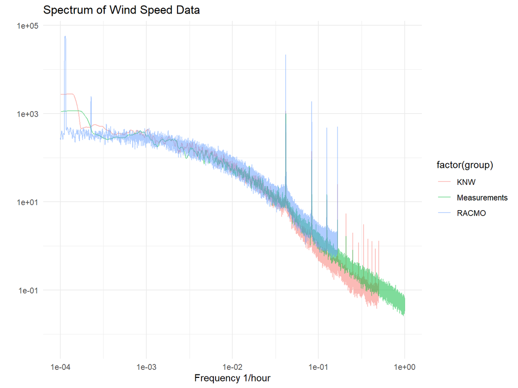

```r
a = cbind(plot_spectrum(data_KNW,column = 'F010',spans=c(11,31))$spectrum_data,group = 'KNW')
b = cbind(plot_spectrum(data_RACMO,column = 'F010',spans=c(11,31))$spectrum_data,group='RACMO')
c = cbind(plot_spectrum(data_measure,column = 'F010',spans=c(11,31))$spectrum_data,group='Measurements')
df_plot = rbind(a,b,c)

peak = data.frame(x=df_plot$Frequency[which.max(df_plot$Spectrum)])
# print((1/peak)/24)

ggplot(df_plot, aes(x=Frequency,y=Spectrum,color=factor(group)))+
  geom_line(alpha=0.5) +
  scale_y_log10() +
  # geom_vline(data = peak,aes(xintercept=x),color='red',lty='dashed',alpha=0.5) +
  scale_x_log10(limits = c(10^(-4),min(1,max(df_plot$Frequency))))+
  labs(title = "Spectrum of Wind Speed Data",
     x = "Frequency 1/hour",
     y = "") +
  theme_minimal()
```

```r
# ggplot(df_plot, aes(x=Frequency,y=Spectrum,color=factor(group)))+
#   geom_line(alpha=0.5) +
#   scale_y_log10() +
#   # geom_vline(data = peak,aes(xintercept=x),color='red',lty='dashed',alpha=0.5) +
#   scale_x_continuous(limits = c(10^(-4),min(1,max(df_plot$Frequency))))+
#   labs(title = "Spectrum of Wind Speed Data",
#      x = "Frequency 1/hour",
#      y = "") +
#   theme_minimal()
```

# 3 Comparing the distributions

## 3.1 QQ and PP plots

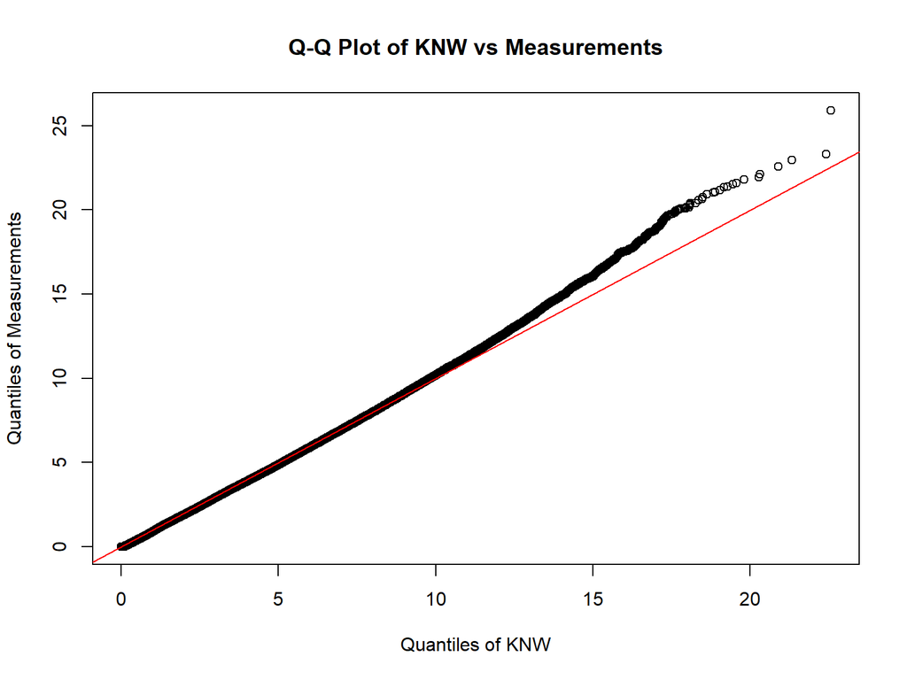

```r
# Q-Q plot to compare data1 and data2
qqplot(data_KNW$F010, data_measure$F010, main = "Q-Q Plot of KNW vs Measurements",
       xlab = "Quantiles of KNW", ylab = "Quantiles of Measurements")
abline(0, 1, col = "red")  # Adds a reference line y=x
```

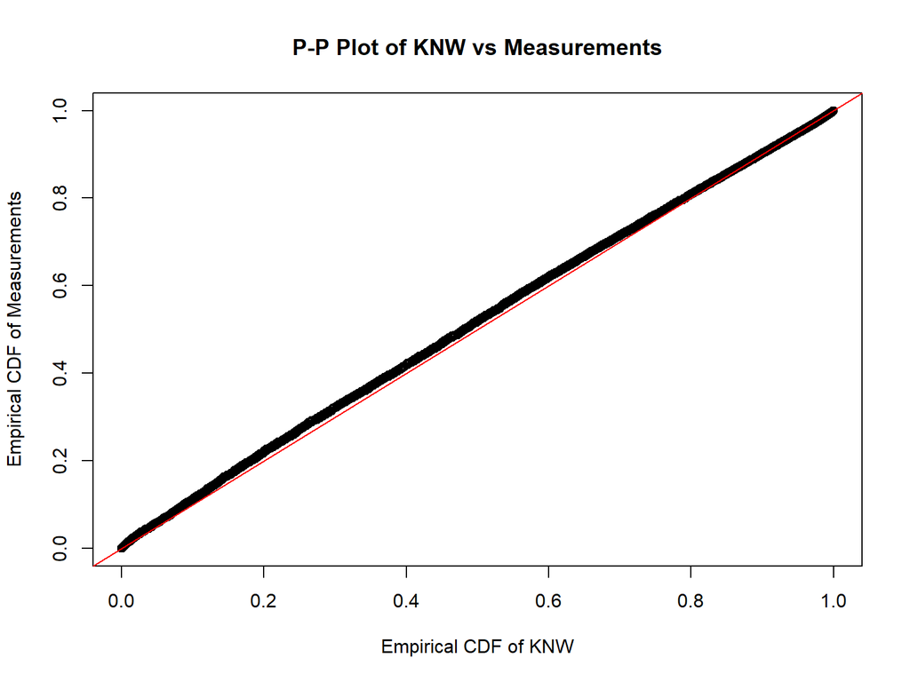

```r
labs = list(xlab = "Empirical CDF of KNW",
            ylab = "Empirical CDF of Measurements",
            main = "P-P Plot of KNW vs Measurements")

pp_plot_compare(data_KNW$F010, data_measure$F010, labs=labs)
```

The PP-plot tells us that the two datasets seems to have the same distribution. However, the QQ-plot shows that the measurements dataset has an heavier tail than the KNW model dataset, this will affect the estimation of the tailindex.

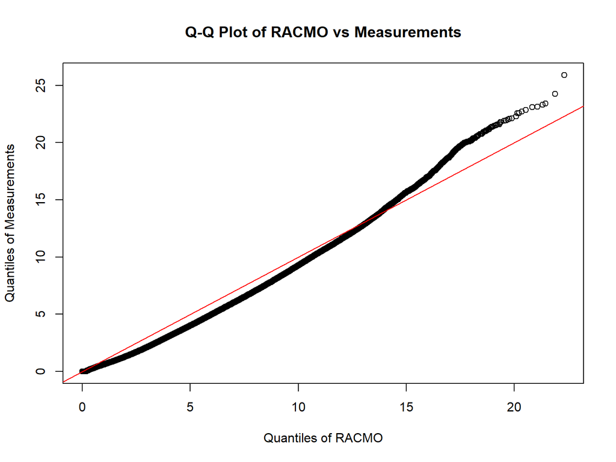

```r
# Q-Q plot to compare data1 and data2
qqplot(data_RACMO$F010, data_measure$F010, main = "Q-Q Plot of RACMO vs Measurements",
       xlab = "Quantiles of RACMO", ylab = "Quantiles of Measurements")
abline(0, 1, col = "red")  # Adds a reference line y=x
```

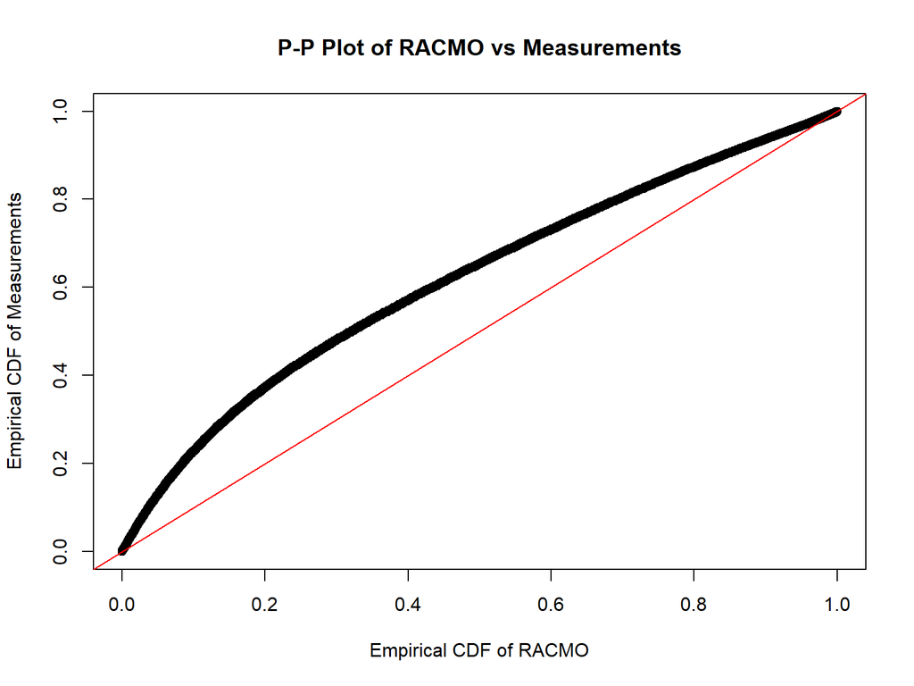

```r
labs = list(xlab = "Empirical CDF of RACMO",
            ylab = "Empirical CDF of Measurements",
            main = "P-P Plot of RACMO vs Measurements")

pp_plot_compare(data_RACMO$F010, data_measure$F010, labs=labs)
```

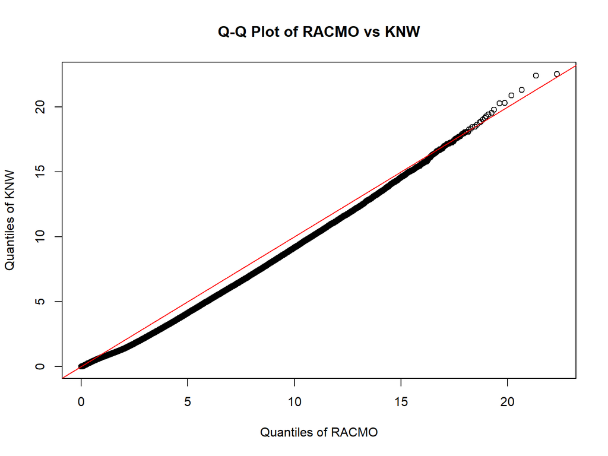

```r
# Q-Q plot to compare data1 and data2
qqplot(data_RACMO$F010, data_KNW$F010, main = "Q-Q Plot of RACMO vs KNW",
       xlab = "Quantiles of RACMO", ylab = "Quantiles of KNW")
abline(0, 1, col = "red")  # Adds a reference line y=x
```

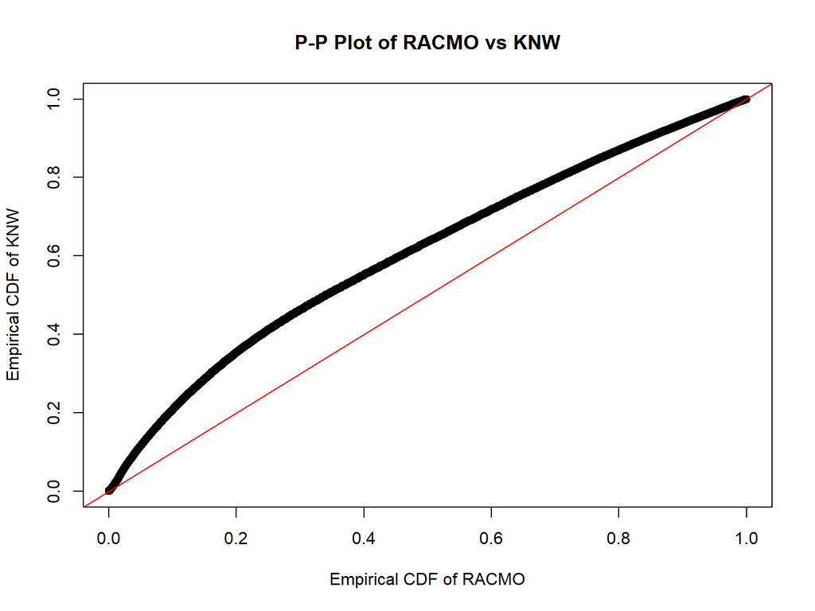

```r
labs = list(xlab = "Empirical CDF of RACMO",
            ylab = "Empirical CDF of KNW",
            main = "P-P Plot of RACMO vs KNW")

pp_plot_compare(data_RACMO$F010, data_KNW$F010, labs=labs)
```

## 3.2 Distributions

### 3.2.1 yearly Block Maxima distributions

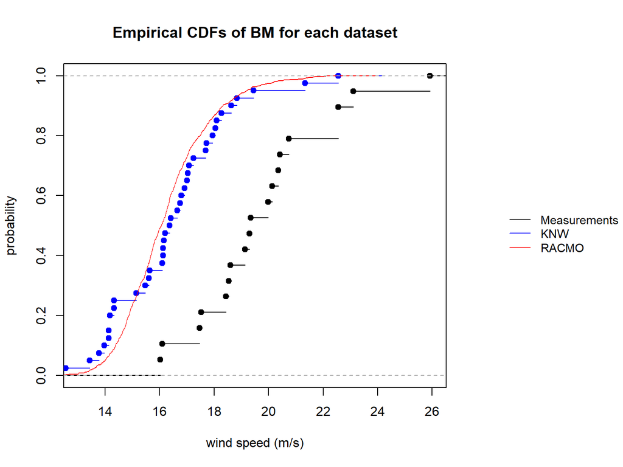

```r
layout(matrix(c(1, 2), 1, 2), widths = c(10, 3))

bm = BM_select(data_measure)
plot(ecdf(bm$max),ylim = c(0,1), xlim=c(13,26),
     xlab = 'wind speed (m/s)',
     ylab = 'probability',
     main = paste0('Empirical CDFs of BM for each dataset'))
bm = BM_select(data_KNW)
lines(ecdf(bm$max),col='blue')

bm = BM_select(data_RACMO)
lines(ecdf(bm$max),col='red')
par(mar = c(1, 1, 1, 2.3))
plot.new()
# Add a legend to the plot
legend(
  "right", # Position of the legend
  legend = c('Measurements','KNW', "RACMO"),
  inset = c(-0.4, 0),
  col = c("black", "blue", "red"),
  lty = c(1, 1, 1),
  bty = "n",
  cex= 0.9,
  xpd=TRUE
)
```

### 3.2.2 Whole datasets distributions

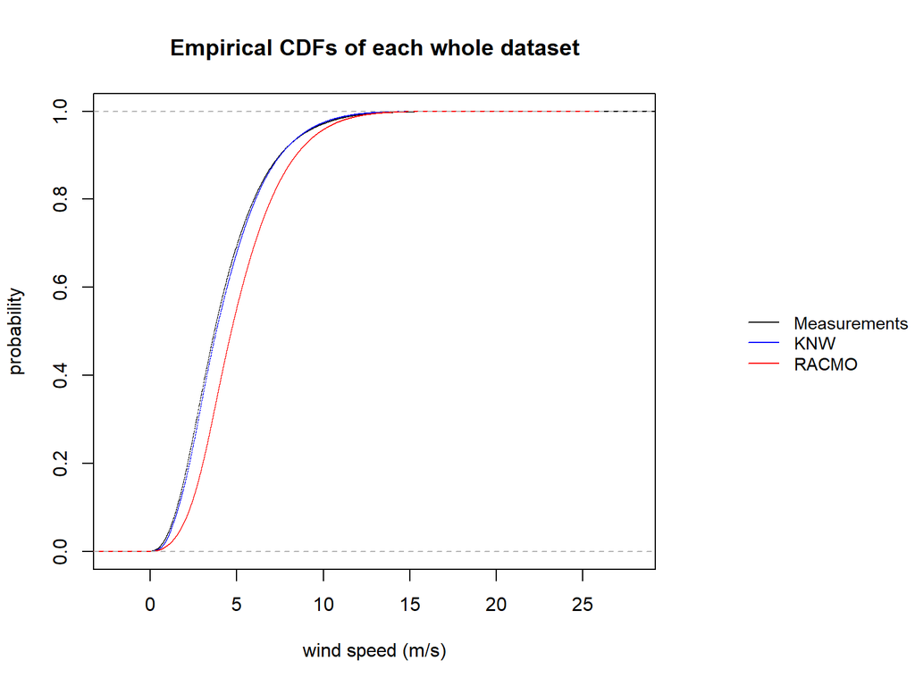

```r
layout(matrix(c(1, 2), 1, 2), widths = c(10, 3))

plot(ecdf(data_measure$F010),ylim = c(0,1),
     xlab = 'wind speed (m/s)',
     ylab = 'probability',
     main = paste0('Empirical CDFs of each whole dataset'))
lines(ecdf(data_KNW$F010),col='blue')

bm = BM_select(data_RACMO)
lines(ecdf(data_RACMO$F010),col='red')
par(mar = c(1, 1, 1, 2.3))
plot.new()
# Add a legend to the plot
legend(
  "right", # Position of the legend
  legend = c('Measurements','KNW', "RACMO"),
  inset = c(-0.4, 0),
  col = c("black", "blue", "red"),
  lty = c(1, 1, 1),
  bty = "n",
  cex= 0.9,
  xpd=TRUE
)
```

KNW and Measurements distributions fits well. However, we see that there are more greater values in RACMO than in KNW and Measurements.

### 3.2.3 Peak over Threshold Distributions

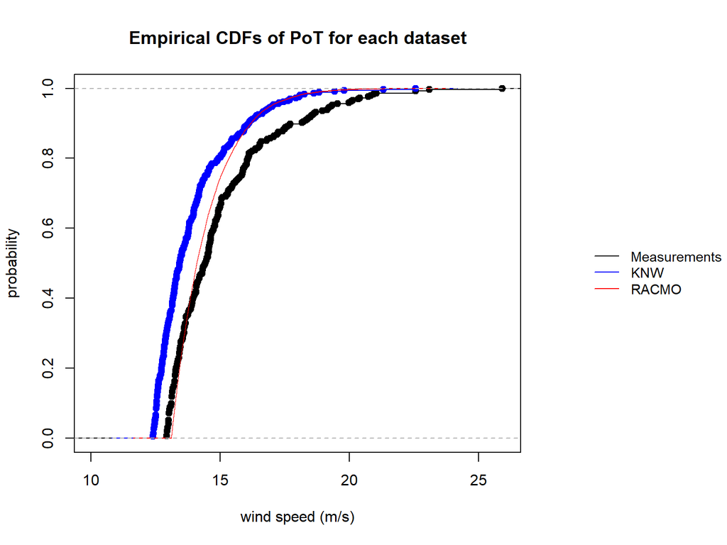

```r
layout(matrix(c(1, 2), 1, 2), widths = c(10, 3))

pot = PoTselect(data_measure$F010,p = 0.005,sep=6*12)$pot
plot(ecdf(pot),ylim = c(0,1), xlim=c(10,26),
     xlab = 'wind speed (m/s)',
     ylab = 'probability',
     main = paste0('Empirical CDFs of PoT for each dataset'))

pot = PoTselect(data_KNW$F010,p = 0.005,sep=12)$pot
lines(ecdf(pot),col='blue')


pot = PoTselect(data_RACMO$F010,p = 0.005,sep=4)$pot
lines(ecdf(pot),col='red')
par(mar = c(1, 1, 1, 2.3))
plot.new()
# Add a legend to the plot
legend(
  "right", # Position of the legend
  legend = c('Measurements','KNW', "RACMO"),
  inset = c(-0.4, 0),
  col = c("black", "blue", "red"),
  lty = c(1, 1, 1),
  bty = "n",
  cex= 0.9,
  xpd=TRUE
)
```

# 4 Uncertainties

## 4.1 Block Maxima estimation

### 4.1.1 Parameters estimation on Measurements with RACMO

First, we’ll use the RACMO data to estimate the tail index and then inject this estimate into the Measurements data to estimate the scale and location.

```r
fit_RACMO = BM_fit(BM_select(data_RACMO),plot=F)

fpar <- function(p, xpar) {
  loc <- matrix(p[1], xpar[1], xpar[2])
  scale <- matrix(p[2], xpar[1], xpar[2])
  shape <- matrix(fit_RACMO['tail'], xpar[1], xpar[2])
  list(loc = loc, scale = scale, shape = shape)
}

bm = BM_select(data_measure)
kwargs = list(start=c(mean(bm$max),sd(bm$max)),fpar=fpar,xpar=c(length(bm$max),1))

trueTail=BM_fit(BM_select(data_measure),plot=F)
modelTail = BM_fit(BM_select(data_measure), kwargs = kwargs,plot=F)

print(fit_RACMO)
```

```
       tail         loc       scale
-0.08771565 15.53743169  1.38583433
```

```r
print(trueTail)
```

```
       tail         loc       scale
-0.09085225 18.77262397  2.07039118
```

```r
print(modelTail)
```

```
       tail         loc       scale
-0.08771565 18.76875355  2.06809858
```

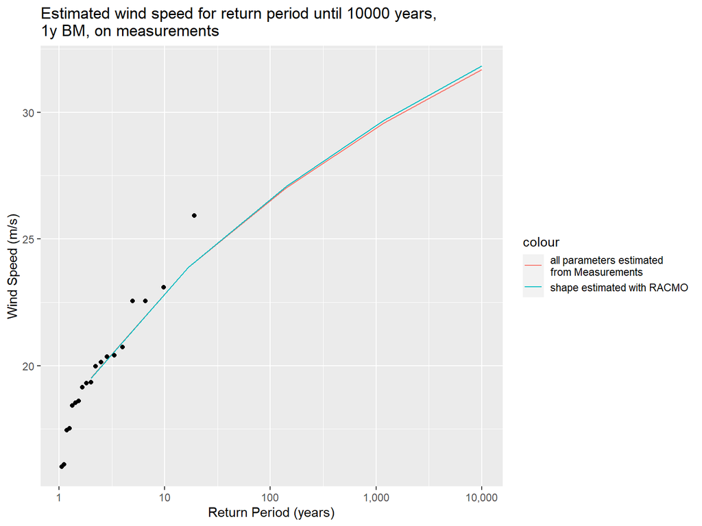

```r
z <- qnorm(1 - 0.05 / 2)
X <- 10^seq(log10(2),log10(10000),length.out = 5)

points <- data.frame(speed = sort(bm$max),return = 1/(1-seq(1/length(bm$max),1-1/length(bm$max),length.out=length(bm$max))))            # observed Values
df <- data.frame(
    return = X,
    original = qgev(p=1 - 1 / X, loc = trueTail['loc'], scale = trueTail['scale'], shape = trueTail['tail']),
    model_est =qgev(p=1 - 1 / X, loc = modelTail['loc'], scale = modelTail['scale'], shape = modelTail['tail'])
  )


ggplot(df, aes(x = return)) +
      geom_line(aes(x=return,y=original,color='all parameters estimated\nfrom Measurements')) +
      geom_line(aes(x=return,y=model_est,color='shape estimated with RACMO')) +
      geom_point(data=points,aes(x = return,y = speed)) +
      scale_x_log10(labels= scales::comma) +
      labs(x = 'Return Period (years)', y = 'Wind Speed (m/s)', title = paste0('Estimated wind speed for return period until 10000 years,\n1y BM, on measurements')) +
      theme(legend.position = "right")
```

```r
print(df)
```

```
       return original model_est
1     2.00000 19.51895  19.51468
2    16.81793 23.87818  23.89011
3   141.42136 27.02408  27.07056
4  1189.20712 29.58442  29.67649
5 10000.00000 31.69135  31.83531
```

### 4.1.2 Confidence Interval

We have one confidence interval for the tail index estimate based on RACMO model data, and two confidence intervals for scale and location.

> For the moment, only the tail index is considered.

To calculate the confidence interval for the wind speed estimate, we use bootstrap estimates from the RACMO dataset. For each bootstrap estimate of the tail index on RACMO, we estimate the scale and loc on the original Measurements data. Then, we estimate the return values with each triplet of parameters (tail,loc,scale) thus estimated.

This gives us a first confidence interval as follows :

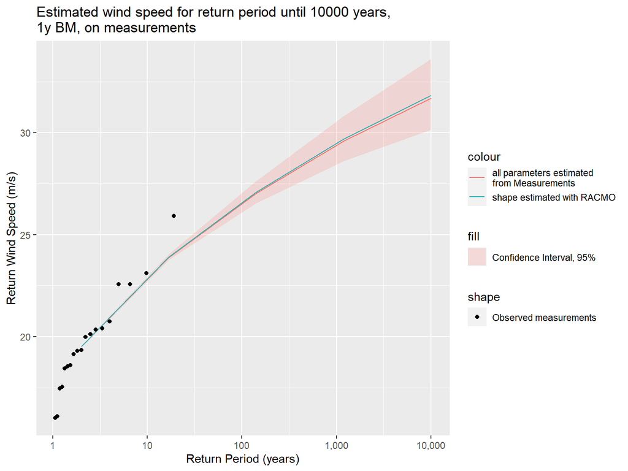

```r
fit_RACMO <- bootstrap(data_RACMO,Nb = 100,method = 'BM')
bm = BM_select(data_measure)

z <- qnorm(1 - 0.05 / 2)
X <- 10^seq(log10(2),log10(10000),length.out = 5)

return_values <- matrix(NA, nrow = 100, ncol = length(X))
for (i in 1:100){
  fpar <- function(p, xpar) {
    loc <- matrix(p[1], xpar[1], xpar[2])
    scale <- matrix(p[2], xpar[1], xpar[2])
    shape <- matrix(fit_RACMO$df$tail[i], xpar[1], xpar[2])
    list(loc = loc, scale = scale, shape = shape)
  }

  kwargs = list(start=c(mean(bm$max),sd(bm$max)),fpar=fpar,xpar=c(length(bm$max),1))

  par = BM_fit(bm, kwargs = kwargs, plot = F)


  return_values[i,] = qgev(p=1 - 1 / X, loc = par['loc'], scale = par['scale'], shape = par['tail'])
}

sd = apply(log(return_values),2,sd)
model_est = qgev(p=1 - 1 / X, loc = modelTail['loc'], scale = modelTail['scale'], shape = modelTail['tail'])



df_plot = cbind(return = X,melt(data.frame(boot=t(return_values))))
points <- data.frame(speed = sort(bm$max),return = 1/(1-seq(1/length(bm$max),1-1/length(bm$max),length.out=length(bm$max))))            # observed Values
df <- data.frame(
    return = X,
    original = qgev(p=1 - 1 / X, loc = trueTail['loc'], scale = trueTail['scale'], shape = trueTail['tail']),
    model_est = model_est,
    lower = model_est*exp(-z*sd),
    upper = model_est*exp(z*sd)
  )


ggplot(df, aes(x = return)) +
      geom_line(aes(x=return,y=original,color='all parameters estimated\nfrom Measurements')) +
      geom_line(aes(x=return,y=model_est,color='shape estimated with RACMO')) +
      geom_ribbon(aes(ymin = lower, ymax = upper, fill = 'Confidence Interval, 95%'), alpha = 0.2) +
      geom_point(data=points,aes(x = return,y = speed,shape='Observed measurements')) +
      # geom_line(data = df_plot, aes(x=return,y=value,line=variable),col='gray',alpha = 0.1)+
      scale_x_log10(labels= scales::comma) +
      labs(x = 'Return Period (years)', y = 'Return Wind Speed (m/s)', title = paste0('Estimated wind speed for return period until 10000 years,\n1y BM, on measurements')) +
      # scale_linetype_manual(name="", values = c('Mean Estimate' = "dashed", 'Without BS' = "solid")) +
      # scale_fill_manual(name = "", values = c('Confidence Interval, 95% bootstrap' = 'blue','Confidence Interval,  95% log(bootstrap)'='red')) +
      # theme_minimal() +
      theme(legend.position = "right")
```

However, this confidence interval does not take into account all uncertainties, only those on the tail index estimate.

> Now, let’s take into account the scale and loc estimation errors.

To do this, for each bootstrap estimate of the tail index on RACMO, we’ll also bootstrap the scale and loc on Measurements. Then, for each pair (scale, loc) bootstrapped on Measurements from each tail index bootstrapped on RACMO (triplet (tail,scale,loc)), we can estimate the return values. Then we can approximate the confidence interval with a normal approximation, considering that the log of the return value is approximatively normal. So we have then :

Let $q$ be the estimation of the original dataset. Let $s_{log}$ be the standard deviation of the $log$ of the bootstrap estimations. Let $z$ be the quantile of normale distribution for 95% confidence ($z\simeq 1.96$).

Then we can compute the standard error as :
$$bounds = qe^{\pm zs_{log}} \simeq qe^{\pm 1.96s_{log}}$$

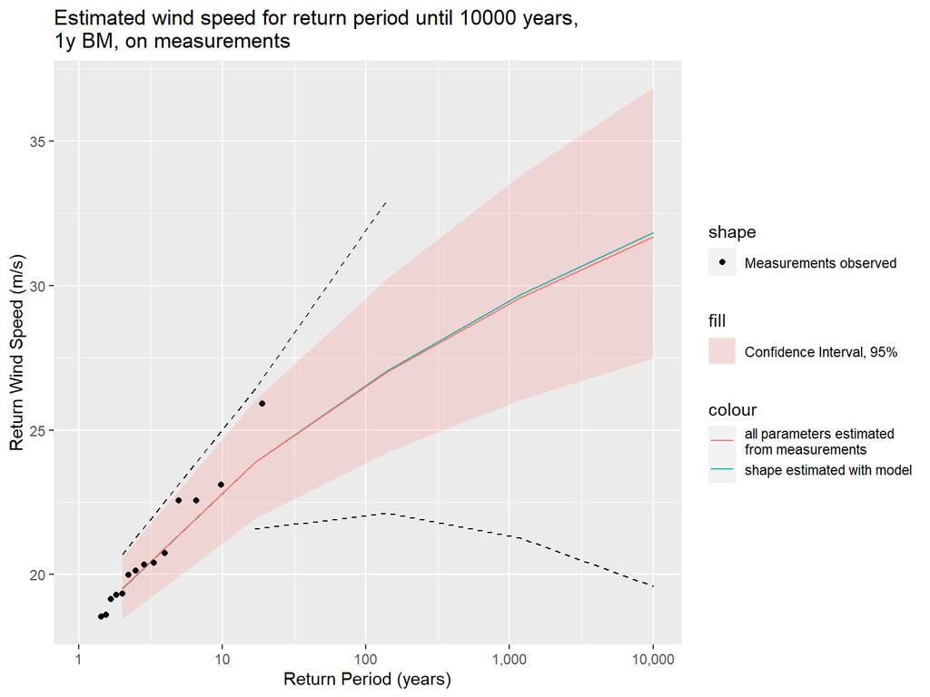

```r
WSEst_model_to_measure_BM(data_measure,data_RACMO,col_model = 'F010')
```

### 4.1.3 KNW

Let’s do the same with KNW instead of RACMO:

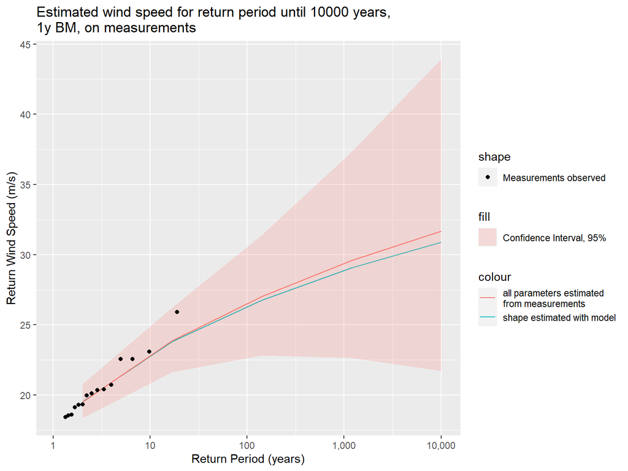

```r
WSEst_model_to_measure_BM(data_measure,data_KNW,col_model = 'F010')
```

# 5 Block maximum

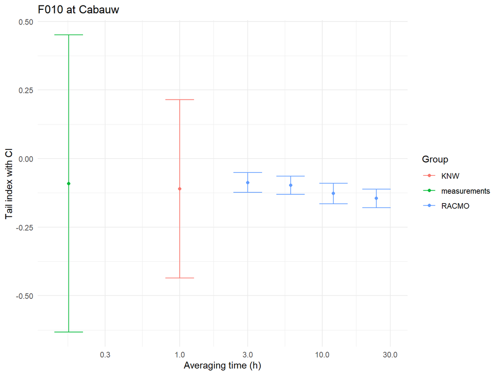

```r
col = 'F010'
alpha = 0.05
labels = c('measurements','KNW','RACMO','RACMO','RACMO','RACMO')
names(labels) = names(data)
out = list()
lower_bounds = c()
upper_bounds =  c()

for (i in names(data)){
    print(i)
    if (!is.null(data[[i]][[col]])){
        out[[i]] <- bootstrap(data[[i]],Nb=300,column = col,method='BM')
        lower_bounds[i] = out[[i]]$original[1] - qnorm(1 - alpha / 2) * sd(out[[i]]$df$tail)
        upper_bounds[i] = out[[i]]$original[1] + qnorm(1 - alpha / 2) * sd(out[[i]]$df$tail)
    }
    else{
        print(paste(col,': data not found'))
    }
}


plot_data <- data.frame(
  x = c(1/6,1,3,6,12,24),
  tail_index = unlist(lapply(out, function(sublist) sublist$original[1])),
  lower_bound = lower_bounds,
  upper_bound = upper_bounds,
  group = as.factor(labels)
)

ggplot(plot_data, aes(x = x, y = tail_index, color = group)) +
  geom_point() +
  geom_errorbar(aes(ymin = lower_bound, ymax = upper_bound), width = 0.2) +
  labs(
    x = "Averaging time (h)",
    y = "Tail index with CI",
    color = "Group",
    title = paste(col,'at Cabauw')
  ) +
  # scale_y_log10()+
  scale_x_log10() +
  theme_minimal()
```

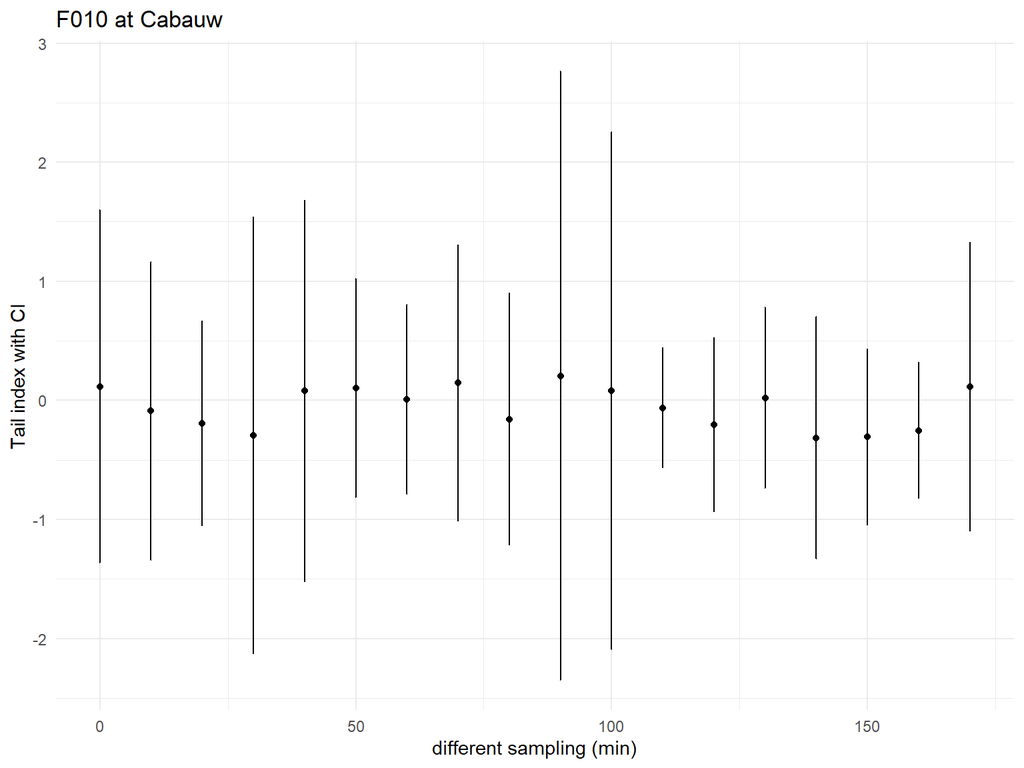

```r
col = 'F010'
alpha = 0.05
labels = minutes(seq(0,170,10))
names(data_measure_3h) = labels
names(labels) = names(data_measure_3h)
out = list()
lower_bounds = c()
upper_bounds =  c()

for (i in names(data_measure_3h)){
    print(i)
    if (!is.null(data_measure_3h[[i]][[col]])){
        out[[i]] <- bootstrap(data_measure_3h[[i]],Nb=300,column = col,method='BM')
        lower_bounds[i] = out[[i]]$original[1] - qnorm(1 - alpha / 2) * sd(out[[i]]$df$tail)
        upper_bounds[i] = out[[i]]$original[1] + qnorm(1 - alpha / 2) * sd(out[[i]]$df$tail)
    }
    else{
        print(paste(col,': data not found'))
    }
}


plot_data <- data.frame(
  x = seq(0,170,10),
  tail_index = unlist(lapply(out, function(sublist) sublist$original[1])),
  lower_bound = lower_bounds,
  upper_bound = upper_bounds,
  group = as.factor(labels)
)

ggplot(plot_data, aes(x = x, y = tail_index, group = group)) +
  geom_point() +
  geom_errorbar(aes(ymin = lower_bound, ymax = upper_bound), width = 0.2) +
  labs(
    x = "different sampling (min)",
    y = "Tail index with CI",
    color = "Group",
    title = paste(col,'at Cabauw')
  ) +
  # scale_y_log10()+
  # scale_x_log10() +
  theme_minimal()
```

```r
a = WSEst_BM(bootstrap(data_measure,Nb = 100,column = 'F010',method = 'BM'),bm = BM_select(data_measure), trueTail = BM_fit(BM_select(data_measure),plot = F))$pred
b = WSEst_BM(bootstrap(data_RACMO,Nb = 100,column = 'F010',method = 'BM'),bm = BM_select(data_RACMO), trueTail = BM_fit(BM_select(data_RACMO),plot = F))$pred

block_length=  "1y"

gg = ggplot(a, aes(x = return)) +
      geom_line(aes(y = mean, linetype = 'Meas : Mean Estimate'),color='black') +
      geom_ribbon(aes(ymin = lower, ymax = upper, fill = 'Meas : Confidence Interval, 95% bootstrap'), alpha = 0.2) +
      # geom_ribbon(aes(ymin = lb, ymax = ub, fill = 'Confidence Interval,  95% log(bootstrap)'), alpha = 0.2) +
      geom_line(aes(x=return,y=original,linetype = 'Meas : Original DS'),color='red') +
      # geom_point(data=points,aes(x = return,y = speed)) +

      geom_line(data = b, aes(y = mean, linetype = 'RACMO : Mean Estimate'),color='black') +
      geom_ribbon(data = b,aes(ymin = lower, ymax = upper, fill = 'RACMO : Confidence Interval, 95% bootstrap'), alpha = 0.2) +
      # geom_ribbon(aes(ymin = lb, ymax = ub, fill = 'Confidence Interval,  95% log(bootstrap)'), alpha = 0.2) +
      geom_line(data = b,aes(x=return,y=original,linetype = 'RACMO : Original DS'),color='blue') +
      # geom_point(data=points,aes(x = return,y = speed)) +

      scale_x_log10(labels= scales::comma) +
      labs(x = 'Return Period (years)', y = 'Wind Speed (m/s)', title = paste0('Estimated wind speed for return period until 10000 years, ', block_length ,'d BM')) +
      scale_linetype_manual(name="", values = c('RACMO : Mean Estimate' = "dashed", 'RACMO : Original DS' = "solid",'Meas : Mean Estimate' = "dashed", 'Meas : Original DS' = "solid")) +
      scale_fill_manual(name = "", values = c('RACMO : Confidence Interval, 95% bootstrap' = 'blue','Meas : Confidence Interval, 95% bootstrap'='red')) +
      theme_minimal() +
      theme(legend.position = "right")

print(gg)
```

[output not shown]

# 6 POT

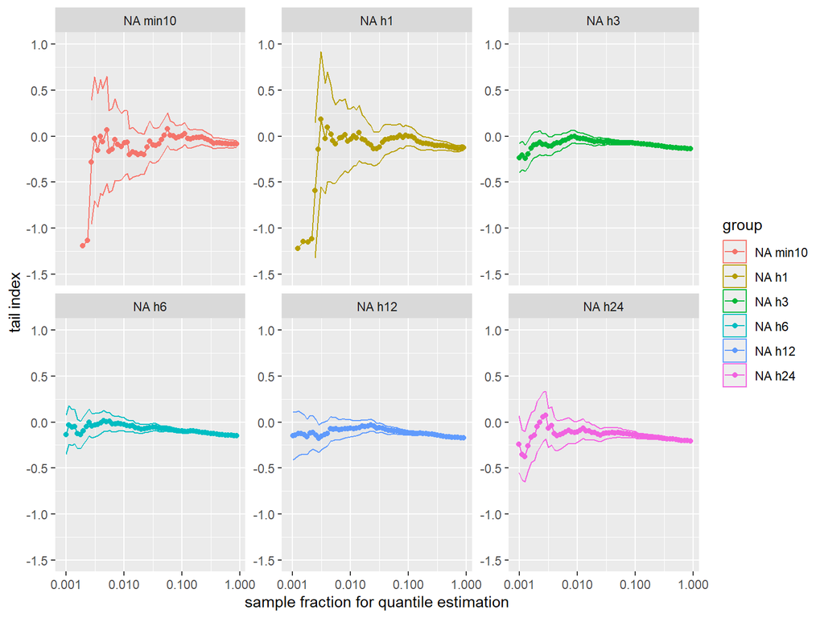

```r
timesep = c(6*12,12,4,2,1,1)
names(timesep) = names(data)
fraq_min = 3
out = list()
for (i in names(data)){
    print(i)
    if (!is.null(data[[i]][[col]])){
        X <- PoTselect(data[[i]]$F010,0.1,timesep[i])
        l0 <- round(10^(seq(-fraq_min, -0, 0.05))*length(X$pot))
        out[[i]] <- FitGP_MLE2(X$pot, 0.1, N= 0, r11= 1, fixedpar= NULL, l0= l0, sigma= Inf, metadata= data.frame(label=paste(labels[i],i)))
        # lower_bounds[i] = out[[i]]$
        # upper_bounds[i] = out[[i]]$
    }
    else{
        print(paste(col,': data not found'))
    }
}
tailindexplot_2(out,fix_y = c(-1.5,1))
```